# Analyzing Data Science Salaries in 2023

Mauro Nunez

[Link to my GitHub Webpage](https://mnunez-6.github.io)

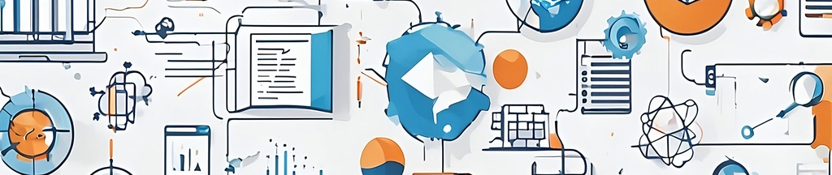

# Project Dataset

This dataset was obtained from the public Kaggle dataset [Data Science Salaries 2023.](https://www.kaggle.com/datasets/arnabchaki/data-science-salaries-2023) The dataset contains a variety of factors regarding Data Science positions, including details about the year of work, experience levels, types of employment, salaries in local currencies and USD, remote work ratios, and other useful factors. This dataset provides a source of information that allows us to analyze trends in salaries, compare job titles, investigate geographical differences, measure the impact of remote work, and examine the correlation between the company size and salaries within the field of Data Science.

# Dataset Columns:

work_year: The year the work and salary payment took place.

experience_level: The level of the employee's experience. (e.g., EN - Entry-level, MI - Mid-level, SE - Senior, EX - Executive)

employment_type: The category of employment. (e.g., FT - Full-time, PT - Part-time, CT - Contract, FL - Freelance)

job_title: The title of the employee's position (e.g., Data Scientist, Data Analyst, etc.)

salary: The salary as reported in the local currency.

salary_currency: The currency in which the salary was reported.

salary_in_usd: The equivalent salary in USD.

employee_residence: The employee's country of residence.

remote_ratio: The proportion of work done remotely. (0 - on-site, 50 - hybrid, 100 - completely remote)

company_location: The geographic location of the company.

company_size: The company's size classification. (S - Small, M - Medium, L - Large)

# Project Goals

The goal of this project is to investigate how salaries differ across various expereince levels, job titles, employment types, and geographical locations. Additonally, we will examine the impact of remote work on salaries and how company size influences compensation. Through the analysis of this dataset, we hope to provide insights into the financial landscape of data science in the modern world, allowing both employers and employees to understand the key factors that drive salary differences in the field of Data Science.

# Research Questions

```python
#importation of necessary libraries
import pandas as pd
import numpy as np
import matplotlib.pyplot as plt
import seaborn as sns


from sklearn.model_selection import train_test_split
from sklearn.linear_model import LinearRegression
from sklearn.metrics import mean_squared_error, r2_score

#mounting of my google drive
from google.colab import drive
drive.mount('/content/drive')

pd.set_option('display.max_columns', None, "display.max_rows", None)
```

## ETL (Extraction, Transform, Load)

We loaded the dataset [Data Science Salaries in 2023](https://https://www.kaggle.com/datasets/arnabchaki/data-science-salaries-2023/data) from Kaggle. This dataset displays the year of work, employee experience level, position title, the salary that was paid in local currency and USD, the country the employee resides in, the remote ratio of the position, and the location and size of the company.

The original dataset contained two additional columns, 'salary' and 'salay_currency'. These columns included salaries in various currencies, making direct comparisons problematic. However, the dataset also includes a 'salary_in_usd' column, which standarizes salaries by converting them all to USD, allowing for consisitent and accurate comparisons. Therefore, we cleaned the dataset by dropping the 'salary' and 'salary_currency' columns, focusing primarily on the 'salary_in_usd' column. Additionally, we reordered the columns of the dataset to group relation information together.

```python
#importation of the Data Science Salaries in 2023
ds_salaries = pd.read_csv('/content/drive/MyDrive/CompSciStuff/TuResearch/CSVs/ds_salaries.csv')

#creates new order of ds_salaries column. Grouping related information.
reorder = ['work_year', 'job_title', 'experience_level', 'employment_type', 'salary', 'salary_currency', 'salary_in_usd','employee_residence', 'remote_ratio', 'company_location', 'company_size']
ds_salaries = ds_salaries[reorder]

#drops the 'salary' and 'salary_currency' columns
ds_salaries = ds_salaries.drop(['salary', 'salary_currency'], axis = 1)

#drops rows with missing values
ds_salaries = ds_salaries.dropna()

ds_salaries.head(10)
```

|  | work_year | job_title | experience_level | employment_type | salary_in_usd | employee_residence | remote_ratio | company_location | company_size |
| --- | --- | --- | --- | --- | --- | --- | --- | --- | --- |
| 0 | 2023 | Principal Data Scientist | SE | FT | 85847 | ES | 100 | ES | L |
| 1 | 2023 | ML Engineer | MI | CT | 30000 | US | 100 | US | S |
| 2 | 2023 | ML Engineer | MI | CT | 25500 | US | 100 | US | S |
| 3 | 2023 | Data Scientist | SE | FT | 175000 | CA | 100 | CA | M |
| 4 | 2023 | Data Scientist | SE | FT | 120000 | CA | 100 | CA | M |
| 5 | 2023 | Applied Scientist | SE | FT | 222200 | US | 0 | US | L |
| 6 | 2023 | Applied Scientist | SE | FT | 136000 | US | 0 | US | L |
| 7 | 2023 | Data Scientist | SE | FT | 219000 | CA | 0 | CA | M |
| 8 | 2023 | Data Scientist | SE | FT | 141000 | CA | 0 | CA | M |
| 9 | 2023 | Data Scientist | SE | FT | 147100 | US | 0 | US | M |

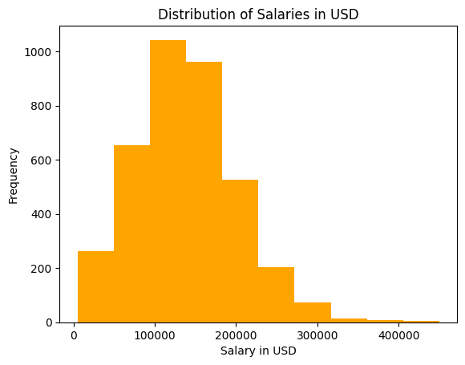

```python
ds_salaries['salary_in_usd'].plot.hist(color = 'orange')
plt.title('Distribution of Salaries in USD')
plt.xlabel('Salary in USD')
plt.ylabel('Frequency')
```

```python
print(ds_salaries['salary_in_usd'].mean())
```

```
137570.38988015978
```

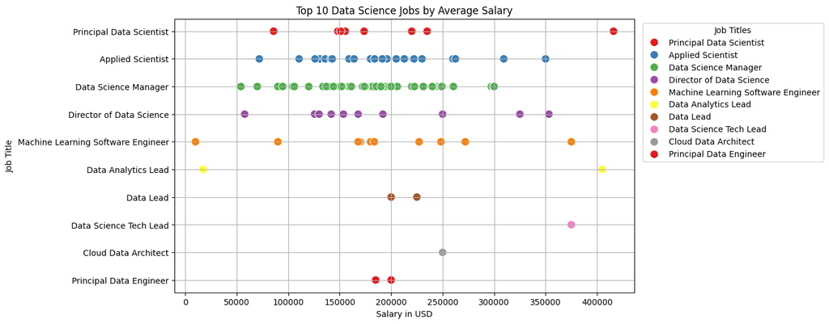

```python
top_10_salaries = ds_salaries.groupby('job_title')['salary_in_usd'].mean().nlargest(10).index

filtered_ds_salaries = ds_salaries[ds_salaries['job_title'].isin(top_10_salaries)]

plt.figure(figsize=(10, 6))
sns.scatterplot(data=filtered_ds_salaries, x='salary_in_usd', y='job_title', hue='job_title', palette='Set1', s = 100)

plt.legend(loc='upper right', bbox_to_anchor=(1.42, 1), title = "Job Titles")
plt.xlabel('Salary in USD')
plt.ylabel('Job Title')
plt.title('Top 10 Data Science Jobs by Average Salary')

plt.grid()
plt.show()
```

baseline - model based on one factor

k fold validation

test with different test sizes

classification - finding job titles

heat maps

box and whiskers